# Prediction_Assignment_Somik

## Background

Using devices such as Jawbone Up, Nike FuelBand, and Fitbit it is now possible to collect a large amount of data about personal activity relatively inexpensively. These type of devices are part of the quantified self movement - a group of enthusiasts who take measurements about themselves regularly to improve their health, to find patterns in their behavior, or because they are tech geeks. One thing that people regularly do is quantify how much of a particular activity they do, but they rarely quantify how well they do it. In this project, your goal will be to use data from accelerometers on the belt, forearm, arm, and dumbell of 6 participants. They were asked to perform barbell lifts correctly and incorrectly in 5 different ways. More information is available from the website here: http://web.archive.org/web/20161224072740/http:/groupware.les.inf.puc-rio.br/har (see the section on the Weight Lifting Exercise Dataset).

## Data

The training data for this project are available here:

https://d396qusza40orc.cloudfront.net/predmachlearn/pml-training.csv

The test data are available here:

https://d396qusza40orc.cloudfront.net/predmachlearn/pml-testing.csv

The data for this project come from this source: http://web.archive.org/web/20161224072740/http:/groupware.les.inf.puc-rio.br/har. If you use the document you create for this class for any purpose please cite them as they have been very generous in allowing their data to be used for this kind of assignment.

## Loading Required Libraries

```r
library(knitr)
library(caret)
```

```r
library(corrplot)
library(rattle)
library(doParallel)
registerDoParallel(detectCores()-1)
```

## Loading Required Data

```r
pml_data<-read.csv("~/R Coursera/pml-training.csv")
pml_predict_data<-read.csv("~/R Coursera/pml-testing.csv")
pml_data<-pml_data[,-1]
pml_predict_data<-pml_predict_data[,-1]
kable(head(pml_data))
```

| user_name | raw_timestamp_part_1 | raw_timestamp_part_2 | cvtd_timestamp | new_window | num_window | roll_belt | pitch_belt | yaw_belt | total_accel_belt | kurtosis_roll_belt | kurtosis_picth_belt | kurtosis_yaw_belt | skewness_roll_belt | skewness_roll_belt.1 | skewness_yaw_belt | max_roll_belt | max_picth_belt | max_yaw_belt | min_roll_belt | min_pitch_belt | min_yaw_belt | amplitude_roll_belt | amplitude_pitch_belt | amplitude_yaw_belt | var_total_accel_belt | avg_roll_belt | stddev_roll_belt | var_roll_belt | avg_pitch_belt | … |
| --- | --- | --- | --- | --- | --- | --- | --- | --- | --- | --- | --- | --- | --- | --- | --- | --- | --- | --- | --- | --- | --- | --- | --- | --- | --- | --- | --- | --- | --- | --- |
| carlitos | 1323084231 | 788290 | 05/12/2011 11:23 | no | 11 | 1.41 | 8.07 | -94.4 | 3 |  |  |  |  |  |  | NA | NA |  | NA | NA |  | NA | NA |  | NA | NA | NA | NA | NA | … |
| carlitos | 1323084231 | 808298 | 05/12/2011 11:23 | no | 11 | 1.41 | 8.07 | -94.4 | 3 |  |  |  |  |  |  | NA | NA |  | NA | NA |  | NA | NA |  | NA | NA | NA | NA | NA | … |
| carlitos | 1323084231 | 820366 | 05/12/2011 11:23 | no | 11 | 1.42 | 8.07 | -94.4 | 3 |  |  |  |  |  |  | NA | NA |  | NA | NA |  | NA | NA |  | NA | NA | NA | NA | NA | … |
| carlitos | 1323084232 | 120339 | 05/12/2011 11:23 | no | 12 | 1.48 | 8.05 | -94.4 | 3 |  |  |  |  |  |  | NA | NA |  | NA | NA |  | NA | NA |  | NA | NA | NA | NA | NA | … |
| carlitos | 1323084232 | 196328 | 05/12/2011 11:23 | no | 12 | 1.48 | 8.07 | -94.4 | 3 |  |  |  |  |  |  | NA | NA |  | NA | NA |  | NA | NA |  | NA | NA | NA | NA | NA | … |
| carlitos | 1323084232 | 304277 | 05/12/2011 11:23 | no | 12 | 1.45 | 8.06 | -94.4 | 3 |  |  |  |  |  |  | NA | NA |  | NA | NA |  | NA | NA |  | NA | NA | NA | NA | NA | … |

```r
kable(head(pml_predict_data))
```

| user_name | raw_timestamp_part_1 | raw_timestamp_part_2 | cvtd_timestamp | new_window | num_window | roll_belt | pitch_belt | yaw_belt | total_accel_belt | kurtosis_roll_belt | kurtosis_picth_belt | kurtosis_yaw_belt | skewness_roll_belt | skewness_roll_belt.1 | skewness_yaw_belt | max_roll_belt | max_picth_belt | max_yaw_belt | min_roll_belt | min_pitch_belt | min_yaw_belt | amplitude_roll_belt | amplitude_pitch_belt | amplitude_yaw_belt | var_total_accel_belt | avg_roll_belt | stddev_roll_belt | var_roll_belt | avg_pitch_belt | … |
| --- | --- | --- | --- | --- | --- | --- | --- | --- | --- | --- | --- | --- | --- | --- | --- | --- | --- | --- | --- | --- | --- | --- | --- | --- | --- | --- | --- | --- | --- | --- |
| pedro | 1323095002 | 868349 | 05/12/2011 14:23 | no | 74 | 123.00 | 27.00 | -4.75 | 20 | NA | NA | NA | NA | NA | NA | NA | NA | NA | NA | NA | NA | NA | NA | NA | NA | NA | NA | NA | NA | … |
| jeremy | 1322673067 | 778725 | 30/11/2011 17:11 | no | 431 | 1.02 | 4.87 | -88.90 | 4 | NA | NA | NA | NA | NA | NA | NA | NA | NA | NA | NA | NA | NA | NA | NA | NA | NA | NA | NA | NA | … |
| jeremy | 1322673075 | 342967 | 30/11/2011 17:11 | no | 439 | 0.87 | 1.82 | -88.50 | 5 | NA | NA | NA | NA | NA | NA | NA | NA | NA | NA | NA | NA | NA | NA | NA | NA | NA | NA | NA | NA | … |
| adelmo | 1322832789 | 560311 | 02/12/2011 13:33 | no | 194 | 125.00 | -41.60 | 162.00 | 17 | NA | NA | NA | NA | NA | NA | NA | NA | NA | NA | NA | NA | NA | NA | NA | NA | NA | NA | NA | NA | … |
| eurico | 1322489635 | 814776 | 28/11/2011 14:13 | no | 235 | 1.35 | 3.33 | -88.60 | 3 | NA | NA | NA | NA | NA | NA | NA | NA | NA | NA | NA | NA | NA | NA | NA | NA | NA | NA | NA | NA | … |
| jeremy | 1322673149 | 510661 | 30/11/2011 17:12 | no | 504 | -5.92 | 1.59 | -87.70 | 4 | NA | NA | NA | NA | NA | NA | NA | NA | NA | NA | NA | NA | NA | NA | NA | NA | NA | NA | NA | NA | … |

Now we will spit the data into a Training and Test Data set

```r
inTrain<-createDataPartition(pml_data$classe,p=0.7,list = FALSE)
pml_training<-pml_data[inTrain,]
pml_testing<-pml_data[-inTrain,]
```

### Data Cleaning

From the Data we can see that there is are a lot of NAs i.e missing data in the dataset. We would need to clean it as it will skew the predictions made by our model if we include those predictor variables.

Before we remove the missing data, we also need to remove the Near Zero Variance Variables as there are many such variables with only one value or more than 90% of one value.

```r
NZV<-nearZeroVar(pml_training)
pml_training<-pml_training[,-NZV]
dim(pml_training)
```

```
## [1] 13737   105
```

For NAs, I have removed variables for which number of values having NAs is greater than 90% of the total row count.

```r
NA_Columns <-sapply(pml_training,function(x) sum(is.na(x)))>0.90*nrow(pml_training)
pml_training<-pml_training[,NA_Columns==FALSE]
```

## Checking Correlations

In order to proceed further,it is important to check whether the predictor variables are highly correlated with each other. In order to do that, I have used cor to find the correlation coefficient and corrplot to visualize the correlations. cor only takes a numerical matrix as input and hence, we need to remove teh categorical variables from our data.

```r
str(pml_training)
```

```
## 'data.frame':    13737 obs. of  58 variables:
##  $ user_name           : Factor w/ 6 levels "adelmo","carlitos",..: 2 2 2 2 2 2 2 2 2 2 ...
##  $ raw_timestamp_part_1: int  1323084231 1323084231 1323084232 1323084232 1323084232 1323084232 1323084232 1323084232 1323084232 1323084232 ...
##  $ raw_timestamp_part_2: int  788290 820366 196328 304277 368296 440390 484323 484434 528316 560359 ...
##  $ cvtd_timestamp      : Factor w/ 20 levels "02/12/2011 13:32",..: 9 9 9 9 9 9 9 9 9 9 ...
##  $ num_window          : int  11 11 12 12 12 12 12 12 12 12 ...
##  $ roll_belt           : num  1.41 1.42 1.48 1.45 1.42 1.42 1.43 1.45 1.43 1.42 ...
##  $ pitch_belt          : num  8.07 8.07 8.07 8.06 8.09 8.13 8.16 8.17 8.18 8.2 ...
##  $ yaw_belt            : num  -94.4 -94.4 -94.4 -94.4 -94.4 -94.4 -94.4 -94.4 -94.4 -94.4 ...
##  $ total_accel_belt    : int  3 3 3 3 3 3 3 3 3 3 ...
##  $ gyros_belt_x        : num  0 0 0.02 0.02 0.02 0.02 0.02 0.03 0.02 0.02 ...
##  $ gyros_belt_y        : num  0 0 0.02 0 0 0 0 0 0 0 ...
##  $ gyros_belt_z        : num  -0.02 -0.02 -0.02 -0.02 -0.02 -0.02 -0.02 0 -0.02 0 ...
##  $ accel_belt_x        : int  -21 -20 -21 -21 -22 -22 -20 -21 -22 -22 ...
##  $ accel_belt_y        : int  4 5 2 4 3 4 2 4 2 4 ...
```

[output cut: 44 more lines]

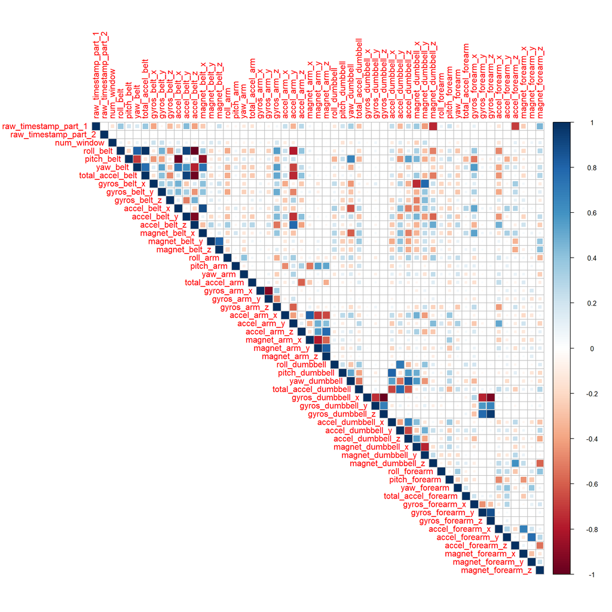

```r
corMatrix <- cor(pml_training[, c(-58,-1,-4)])
corrplot(corMatrix,method = "square",type = "upper")
```

## Modelling

For this analysis, I would be using three ML algorithms, Basic Tree model, Random Forest and Gradient Boosting Model.

### CART MODEL

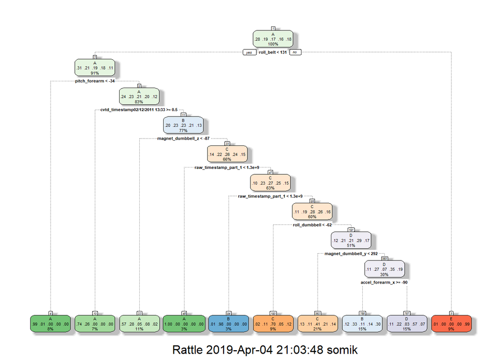

```r
tree_model<-train(classe~.,data=pml_training,method="rpart")
fancyRpartPlot(tree_model$finalModel)
```

### Random Forest

We will use K-fold cross validation method to build this model with 3 samples.

```r
rfcontrol<-trainControl(method="cv",allowParallel = TRUE,number = 3)
RF_model<-train(classe~.,data=pml_training,method="rf",trControl=rfcontrol)
print(RF_model)
```

```
## Random Forest
##
## 13737 samples
##    57 predictor
##     5 classes: 'A', 'B', 'C', 'D', 'E'
##
## No pre-processing
## Resampling: Cross-Validated (3 fold)
## Summary of sample sizes: 9159, 9157, 9158
## Resampling results across tuning parameters:
##
##   mtry  Accuracy   Kappa
##    2    0.9863146  0.9826858
##   40    0.9986170  0.9982507
##   79    0.9977433  0.9971455
##
## Accuracy was used to select the optimal model using the largest value.
## The final value used for the model was mtry = 40.
```

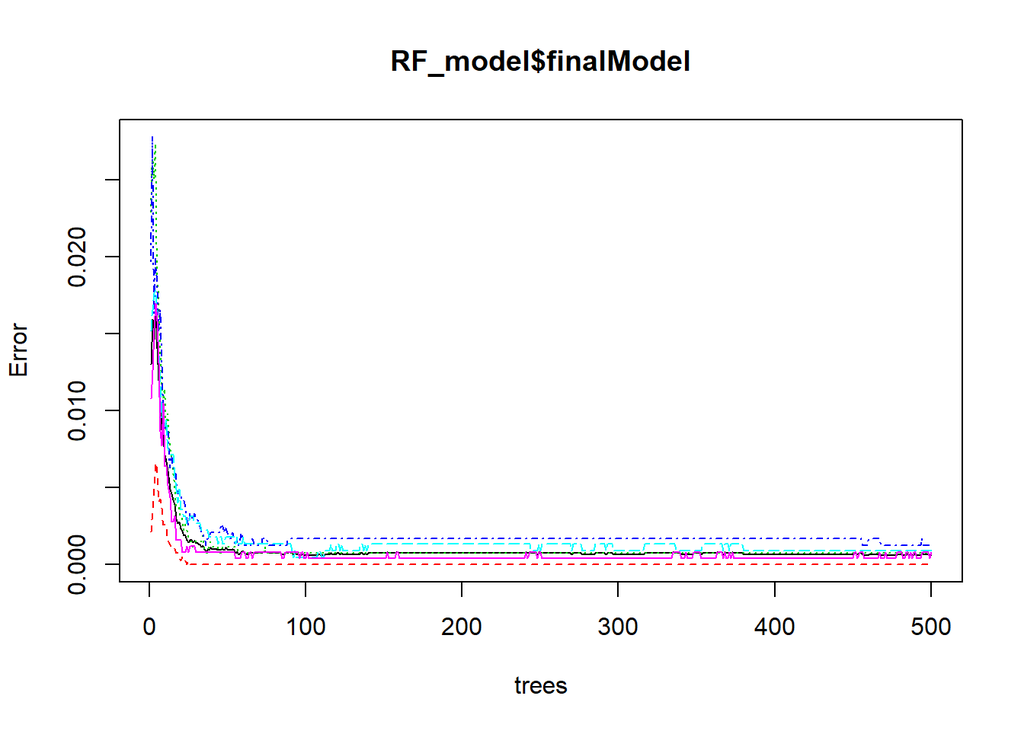

```r
plot(RF_model$finalModel)
```

### Gradient Boosting Method

We will use K-fold cross validation method to build this model with 5 samples.

```r
gbControl<-trainControl(method = "cv",allowParallel = TRUE, number = 5)
GBM_model<-train(classe~.,data=pml_training,method="gbm",trControl=gbControl,verbose=FALSE)
print(GBM_model)
```

```
## Stochastic Gradient Boosting
##
## 13737 samples
##    57 predictor
##     5 classes: 'A', 'B', 'C', 'D', 'E'
##
## No pre-processing
## Resampling: Cross-Validated (5 fold)
## Summary of sample sizes: 10990, 10989, 10991, 10989, 10989
## Resampling results across tuning parameters:
##
##   interaction.depth  n.trees  Accuracy   Kappa
##   1                   50      0.8290030  0.7830568
##   1                  100      0.8985218  0.8714824
##   1                  150      0.9251650  0.9052023
##   2                   50      0.9575600  0.9462746
##   2                  100      0.9860236  0.9823191
##   2                  150      0.9914831  0.9892274
##   3                   50      0.9826753  0.9780815
##   3                  100      0.9923568  0.9903329
##   3                  150      0.9954868  0.9942917
##
## Tuning parameter 'shrinkage' was held constant at a value of 0.1
##
## Tuning parameter 'n.minobsinnode' was held constant at a value of 10
## Accuracy was used to select the optimal model using the largest value.
## The final values used for the model were n.trees = 150,
##  interaction.depth = 3, shrinkage = 0.1 and n.minobsinnode = 10.
```

## Prediction using Test Data and confusion Matrix

```r
predict_tree<-predict(tree_model,pml_testing)
predict_rf<-predict(RF_model,pml_testing)
predict_GBM<-predict(GBM_model,pml_testing)
```

```r
confusionMatrix(predict_tree,pml_testing$classe)
```

```
## Confusion Matrix and Statistics
##
##           Reference
## Prediction    A    B    C    D    E
##          A 1247  267   30   39   13
##          B  140  478  110  143  286
##          C  165  204  860  325  235
##          D  119  190   26  457   79
##          E    3    0    0    0  469
##
## Overall Statistics
##
##                Accuracy : 0.5966
##                  95% CI : (0.5839, 0.6092)
##     No Information Rate : 0.2845
##     P-Value [Acc > NIR] : < 2.2e-16
##
##                   Kappa : 0.4912
##  Mcnemar's Test P-Value : < 2.2e-16
##
## Statistics by Class:
##
##                      Class: A Class: B Class: C Class: D Class: E
## Sensitivity            0.7449  0.41967   0.8382  0.47407  0.43346
## Specificity            0.9171  0.85693   0.8088  0.91587  0.99938
## Pos Pred Value         0.7813  0.41314   0.4807  0.52468  0.99364
## Neg Pred Value         0.9004  0.86019   0.9595  0.89888  0.88675
## Prevalence             0.2845  0.19354   0.1743  0.16381  0.18386
## Detection Rate         0.2119  0.08122   0.1461  0.07766  0.07969
## Detection Prevalence   0.2712  0.19660   0.3040  0.14800  0.08020
## Balanced Accuracy      0.8310  0.63830   0.8235  0.69497  0.71642
```

```r
confusionMatrix(predict_rf,pml_testing$classe)
```

```
## Confusion Matrix and Statistics
##
##           Reference
## Prediction    A    B    C    D    E
##          A 1674    0    0    0    0
##          B    0 1139    0    0    0
##          C    0    0 1026    3    0
##          D    0    0    0  961    2
##          E    0    0    0    0 1080
##
## Overall Statistics
##
##                Accuracy : 0.9992
##                  95% CI : (0.998, 0.9997)
##     No Information Rate : 0.2845
##     P-Value [Acc > NIR] : < 2.2e-16
##
##                   Kappa : 0.9989
##  Mcnemar's Test P-Value : NA
##
## Statistics by Class:
##
##                      Class: A Class: B Class: C Class: D Class: E
## Sensitivity            1.0000   1.0000   1.0000   0.9969   0.9982
## Specificity            1.0000   1.0000   0.9994   0.9996   1.0000
## Pos Pred Value         1.0000   1.0000   0.9971   0.9979   1.0000
## Neg Pred Value         1.0000   1.0000   1.0000   0.9994   0.9996
## Prevalence             0.2845   0.1935   0.1743   0.1638   0.1839
## Detection Rate         0.2845   0.1935   0.1743   0.1633   0.1835
## Detection Prevalence   0.2845   0.1935   0.1749   0.1636   0.1835
## Balanced Accuracy      1.0000   1.0000   0.9997   0.9982   0.9991
```

```r
confusionMatrix(predict_GBM,pml_testing$classe)
```

```
## Confusion Matrix and Statistics
##
##           Reference
## Prediction    A    B    C    D    E
##          A 1674    0    0    0    0
##          B    0 1132    0    0    0
##          C    0    4 1024    3    0
##          D    0    3    2  961    5
##          E    0    0    0    0 1077
##
## Overall Statistics
##
##                Accuracy : 0.9971
##                  95% CI : (0.9954, 0.9983)
##     No Information Rate : 0.2845
##     P-Value [Acc > NIR] : < 2.2e-16
##
##                   Kappa : 0.9963
##  Mcnemar's Test P-Value : NA
##
## Statistics by Class:
##
##                      Class: A Class: B Class: C Class: D Class: E
## Sensitivity            1.0000   0.9939   0.9981   0.9969   0.9954
## Specificity            1.0000   1.0000   0.9986   0.9980   1.0000
## Pos Pred Value         1.0000   1.0000   0.9932   0.9897   1.0000
## Neg Pred Value         1.0000   0.9985   0.9996   0.9994   0.9990
## Prevalence             0.2845   0.1935   0.1743   0.1638   0.1839
## Detection Rate         0.2845   0.1924   0.1740   0.1633   0.1830
## Detection Prevalence   0.2845   0.1924   0.1752   0.1650   0.1830
## Balanced Accuracy      1.0000   0.9969   0.9983   0.9974   0.9977
```

Hence, Random Forest model would be the obvious choice amongst the three models.

## Prediction

```r
prediction<-predict(RF_model,pml_predict_data)
prediction
```

```
##  [1] B A B A A E D B A A B C B A E E A B B B
## Levels: A B C D E
```